# Proyecto Final Ciencia de Datos

Francisco de Borja Insausti Lomba

2026-03-06

## ————————————————————————————–

# EJERCICIO 1 – ANÁLISIS EXPLORATORIO

Lo primero que haremos es cargar y preparar el archivo con su dataset

1. **Cargamos las librerias**

```r
library(ggplot2)
library(dplyr)
library(gridExtra)
library(GGally)
```

2. **Cargamos los datos**

```r
churn_data <- read.csv("churn_data.csv")
```

## ————————————————————————————–

## Apartado 1 - Análisis y preparación de los datos

Empezaremos preparando los datos para su posterior analisis.

#### 1.1 Omitimos Valores nulos

```r
churn_data <- na.omit(churn_data)
```

#### 1.2 Visualizamos datos mediante Summary()

```r
summary(churn_data)
```

```
##   customerID           gender          SeniorCitizen      Partner
##  Length:7032        Length:7032        Min.   :0.0000   Length:7032
##  Class :character   Class :character   1st Qu.:0.0000   Class :character
##  Mode  :character   Mode  :character   Median :0.0000   Mode  :character
##                                        Mean   :0.1624
##                                        3rd Qu.:0.0000
##                                        Max.   :1.0000
##   Dependents            tenure      PhoneService       MultipleLines
##  Length:7032        Min.   : 1.00   Length:7032        Length:7032
##  Class :character   1st Qu.: 9.00   Class :character   Class :character
##  Mode  :character   Median :29.00   Mode  :character   Mode  :character
##                     Mean   :32.42
##                     3rd Qu.:55.00
##                     Max.   :72.00
##  InternetService    OnlineSecurity     OnlineBackup       DeviceProtection
##  Length:7032        Length:7032        Length:7032        Length:7032
##  Class :character   Class :character   Class :character   Class :character
##  Mode  :character   Mode  :character   Mode  :character   Mode  :character
##
##
##
##  TechSupport        StreamingTV        StreamingMovies      Contract
##  Length:7032        Length:7032        Length:7032        Length:7032
##  Class :character   Class :character   Class :character   Class :character
##  Mode  :character   Mode  :character   Mode  :character   Mode  :character
##
##
##
##  PaperlessBilling   PaymentMethod      MonthlyCharges    TotalCharges
##  Length:7032        Length:7032        Min.   : 18.25   Min.   :  18.8
##  Class :character   Class :character   1st Qu.: 35.59   1st Qu.: 401.4
##  Mode  :character   Mode  :character   Median : 70.35   Median :1397.5
##                                        Mean   : 64.80   Mean   :2283.3
##                                        3rd Qu.: 89.86   3rd Qu.:3794.7
##                                        Max.   :118.75   Max.   :8684.8
##     Churn
##  Length:7032
##  Class :character
##  Mode  :character
##
##
##
```

#### 1.3 Trabajamos los datos

En tercer lugar **procedemos a responder o indicar las siguientes cuestiones solicitadas:**

##### 1.3.1 Nº de Variables y tipo de dato

`Indicar cuántas variables has visualizado en el conjunto de datos y cuáles son, especificando el tipo de dato asociado a cada una de ellas.`

**Respuesta**:

En total se han visualizado **21 variables**, siendo estos sus tipos de datos:

| Variable | Tipo de Dato |
| --- | --- |
| **customerID** | Character |
| **gender** | Character |
| **SeniorCitizen** | Numeric |
| **Partner** | Character |
| **Dependents** | Character |
| **tenure** | Numeric |
| **PhoneService** | Character |
| **MultipleLines** | Character |
| **InternetService** | Character |
| **OnlineSecurity** | Character |
| **OnlineBackup** | Character |
| **DeviceProtection** | Character |
| **TechSupport** | Character |
| **StreamingTV** | Character |
| **StreamingMovies** | Character |
| **Contract** | Character |
| **PaperlessBilling** | Character |
| **PaymentMethod** | Character |
| **MonthlyCharges** | Numeric |
| **TotalCharges** | Numeric |
| **Churn** | Character |

##### 1.3.2 Revisar la clasificación de variables y reemplazar variables erroneas

`Clasificar las variables como cualitativas o cuantitativas. Es necesario que revises todas las variables detenidamente, ya que algunas variables numéricas podrían considerarse cualitativas.`

`En caso de que localices una variable cualitativa que inicialmente sea de tipo numérico deberás remplazar sus valores haciendo uso de la función replace() o de una opción equivalente.`

**Respuesta**:

De todas las variables `SeniorCitizen` aparece como numérica y en realidad es cualitativa, ya que todos sus valores estan entre 0 y 1.

*Se suele utilizar los valores 0 y 1 para contestar respuestas “SI” o “NO” en encuestas*

Procedemos a sustituir *los valores 0 y 1 por NO y SI.*

```r
churn_data$SeniorCitizen <- replace(churn_data$SeniorCitizen, churn_data$SeniorCitizen == 0, "NO")
churn_data$SeniorCitizen <- replace(churn_data$SeniorCitizen, churn_data$SeniorCitizen == 1, "SI")
```

##### 1.3.3 Factorizar las variables

`Factorizar todas las variables categóricas, entre las que se encuentran todas las variables cualitativas.`

**Respuesta**:

- 1º Generamos un vector con los nombres de las variables cualitativas

```r
variables_cualitativas <- c("gender", "SeniorCitizen", "Partner", "Dependents",
                            "PhoneService", "MultipleLines", "InternetService",
                            "OnlineSecurity", "OnlineBackup", "DeviceProtection",
                            "TechSupport", "StreamingTV", "StreamingMovies",
                            "Contract", "PaperlessBilling", "PaymentMethod", "Churn")
```

- 2º Aplicamos la factorizacion

```r
churn_data[variables_cualitativas] <- lapply(churn_data[variables_cualitativas], as.factor)
```

##### 1.3.4 Crear nuevo dataframe sin columna “customerID”

`Crearás un nuevo dataframe llamado “ clean_data” sin la columna llamada: “customerID”`

**Respuesta**:

```r
clean_data <- churn_data %>% select(-customerID)
```

Con estas acciones **ya disponemos de los datos preparados para trabajar con ellos**

## ————————————————————————————–

## Apartado 2 – Diagramas e histogramas

Lo primero que vamos a realizar es generar 2 tipos gráficos:

- *Diagramas de frecuencia** para cada una de las **variables cualitativas**
- *Histogramas* para cada una de las **variables cuantitativas**

#### 2.1 Diagramas de frecuencia

Dado que el numero de variables cualitativas **es alto** *(17 variables en total)* he decidido agrupar las variables en bloques para:

- Agrupar variables que **tienen similitudes o definen un mismo perfíl**
- Ordenar los graficos **para mejorar la visualización**

##### 2.1.1 Variables de Perfil Demografico

Estas variables **ayudan a definir el perfil demografico de los clientes**

Entre estas variables podemos encontrar las variables de:

`gender` `SeniorCitizen` `Partner` `Dependents`

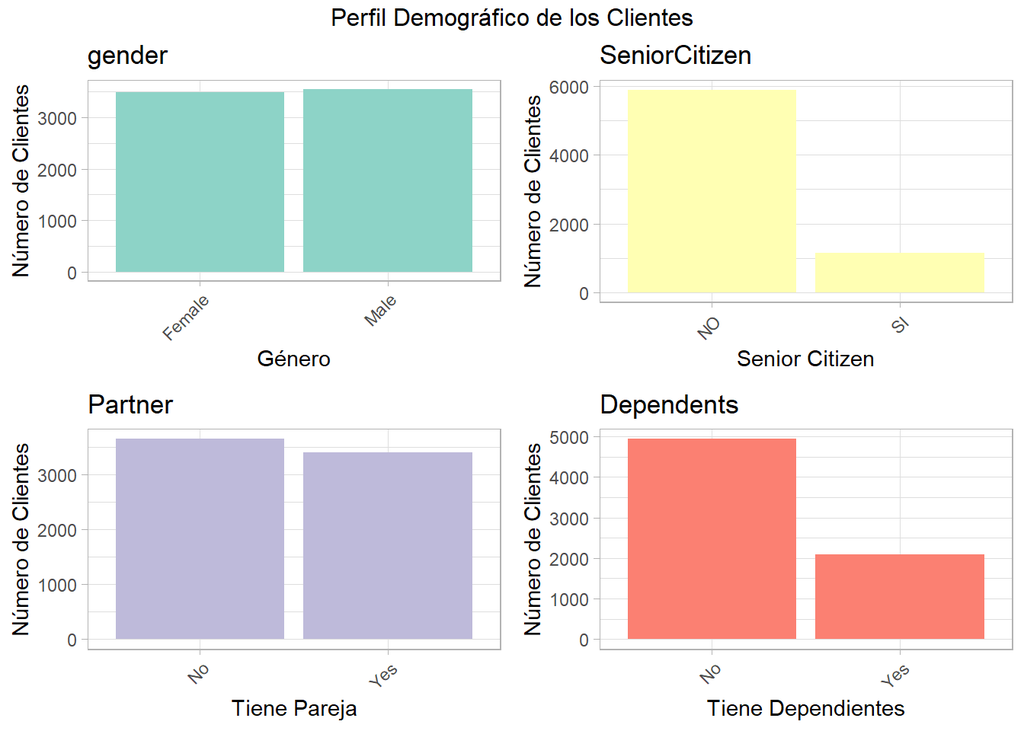

```r
d1 <- ggplot(clean_data, aes(x = gender)) +
      geom_bar(fill = "#8dd3c7") + theme_light() +
      labs(title = "gender", x = "Género", y = "Número de Clientes") +
      theme(axis.text.x = element_text(angle = 45, hjust = 1))

d2 <- ggplot(clean_data, aes(x = SeniorCitizen)) +
      geom_bar(fill = "#ffffb3") + theme_light() +
      labs(title = "SeniorCitizen", x = "Senior Citizen", y = "Número de Clientes") +
      theme(axis.text.x = element_text(angle = 45, hjust = 1))

d3 <- ggplot(clean_data, aes(x = Partner)) +
      geom_bar(fill = "#bebada") + theme_light() +
      labs(title = "Partner", x = "Tiene Pareja", y = "Número de Clientes") +
      theme(axis.text.x = element_text(angle = 45, hjust = 1))

d4 <- ggplot(clean_data, aes(x = Dependents)) +
      geom_bar(fill = "#fb8072") + theme_light() +
      labs(title = "Dependents", x = "Tiene Dependientes", y = "Número de Clientes") +
      theme(axis.text.x = element_text(angle = 45, hjust = 1))

grid.arrange(d1, d2, d3, d4, ncol = 2, top = "Perfil Demográfico de los Clientes")
```

##### 2.1.2 Variables de Servicios Contratados para lineas moviles

Estas variables **tienen que ver con productos contratados por clientes con las lineas moviles**

Entre estas variables podemos encontrar las variables de:

`PhoneService` `MultipleLines` `DeviceProtection`

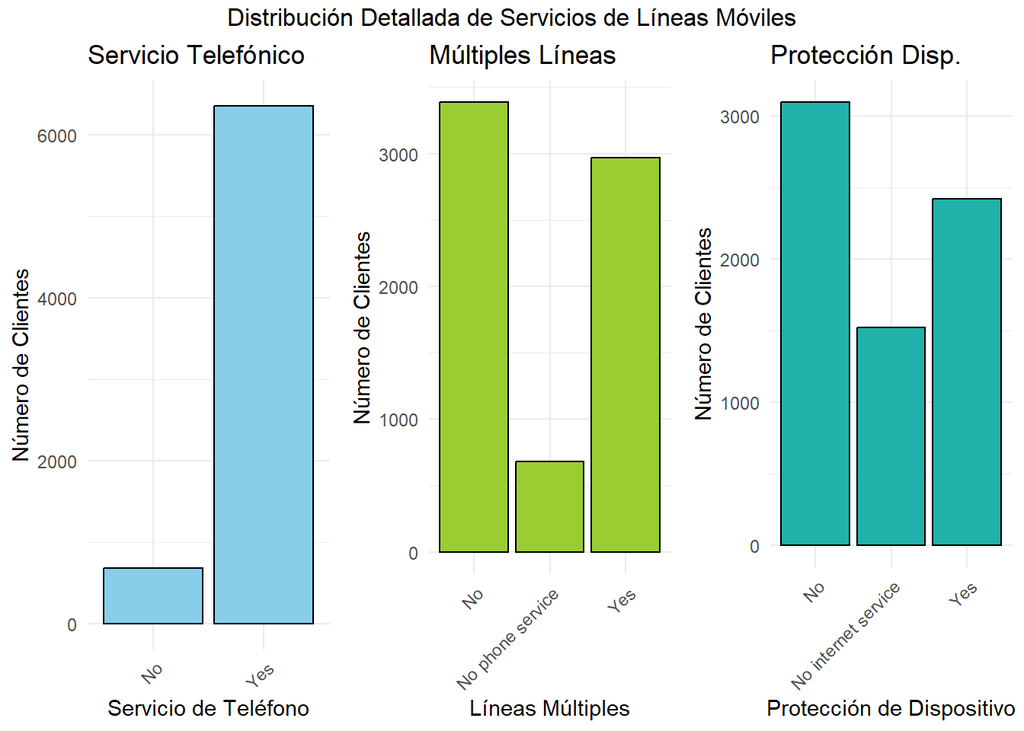

```r
s1 <- ggplot(clean_data, aes(x = PhoneService)) +
      geom_bar(fill = "skyblue", color = "black") +
      theme_minimal() + labs(title = "Servicio Telefónico", x = "Servicio de Teléfono", y = "Número de Clientes") +
      theme(axis.text.x = element_text(angle = 45, hjust = 1))

s2 <- ggplot(clean_data, aes(x = MultipleLines)) +
      geom_bar(fill = "olivedrab3", color = "black") +
      theme_minimal() + labs(title = "Múltiples Líneas", x = "Líneas Múltiples", y = "Número de Clientes") +
      theme(axis.text.x = element_text(angle = 45, hjust = 1))

s6 <- ggplot(clean_data, aes(x = DeviceProtection)) +
      geom_bar(fill = "lightseagreen", color = "black") +
      theme_minimal() + labs(title = "Protección Disp.", x = "Protección de Dispositivo", y = "Número de Clientes") +
      theme(axis.text.x = element_text(angle = 45, hjust = 1))

grid.arrange(s1, s2, s6, ncol = 3, top = "Distribución Detallada de Servicios de Líneas Móviles")
```

##### 2.1.3 Variables de servicios contratados para internet

Estas variables **tienen que ver con productos contratados por clientes con servicios vinculados a internet**

Entre estas variables podemos encontrar las variables de:

`InternetService` `OnlineSecurity` `OnlineBackup`

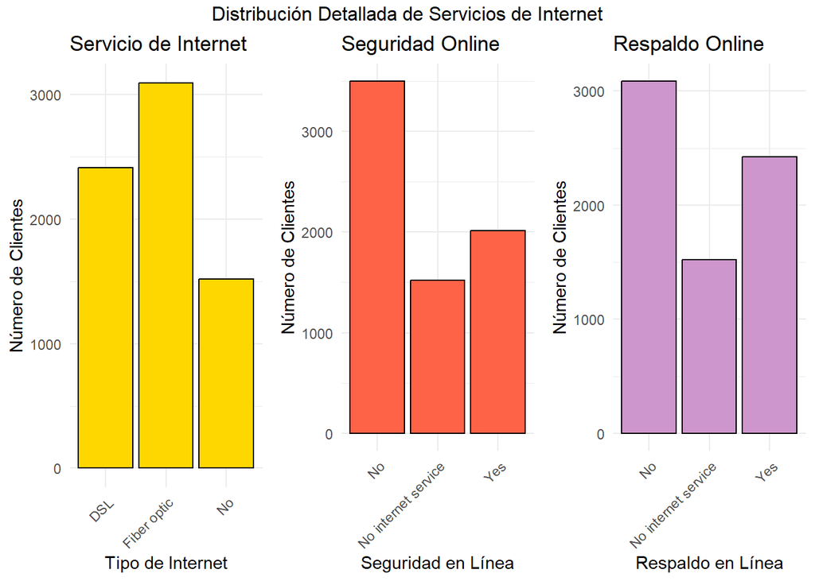

```r
s3 <- ggplot(clean_data, aes(x = InternetService)) +
      geom_bar(fill = "gold", color = "black") +
      theme_minimal() + labs(title = "Servicio de Internet", x = "Tipo de Internet", y = "Número de Clientes") +
      theme(axis.text.x = element_text(angle = 45, hjust = 1))

s4 <- ggplot(clean_data, aes(x = OnlineSecurity)) +
      geom_bar(fill = "tomato", color = "black") +
      theme_minimal() + labs(title = "Seguridad Online", x = "Seguridad en Línea", y = "Número de Clientes") +
      theme(axis.text.x = element_text(angle = 45, hjust = 1))

s5 <- ggplot(clean_data, aes(x = OnlineBackup)) +
      geom_bar(fill = "plum3", color = "black") +
      theme_minimal() + labs(title = "Respaldo Online", x = "Respaldo en Línea", y = "Número de Clientes") +
      theme(axis.text.x = element_text(angle = 45, hjust = 1))

grid.arrange(s3, s4, s5, ncol = 3, top = "Distribución Detallada de Servicios de Internet")
```

##### 2.1.4 Variables de Servicios Contratados para Smart TV

Estas variables **tienen que ver con productos contratados por clientes con servicios vinculados a la television**

Entre estas variables podemos encontrar las variables de:

`TechSupport` `StreamingTV` `StreamingMovies`

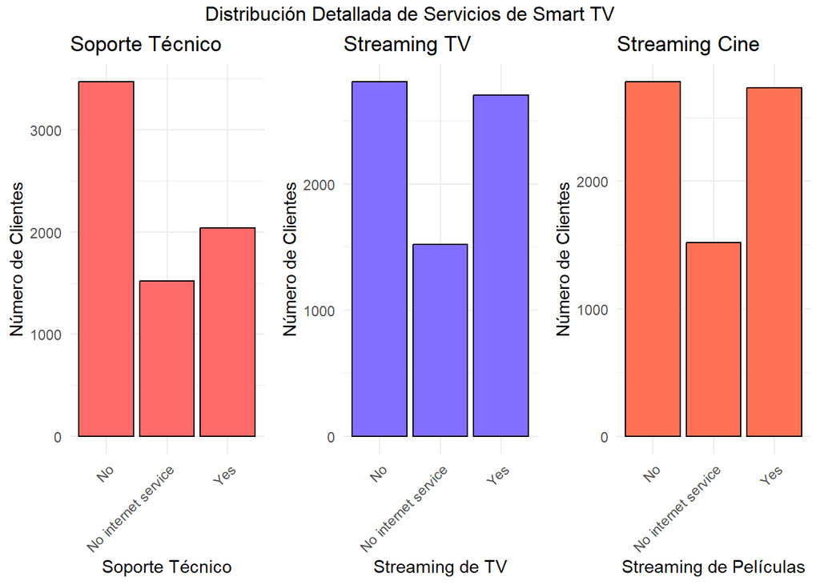

```r
s7 <- ggplot(clean_data, aes(x = TechSupport)) +
      geom_bar(fill = "indianred1", color = "black") +
      theme_minimal() + labs(title = "Soporte Técnico", x = "Soporte Técnico", y = "Número de Clientes") +
      theme(axis.text.x = element_text(angle = 45, hjust = 1))

s8 <- ggplot(clean_data, aes(x = StreamingTV)) +
      geom_bar(fill = "slateblue1", color = "black") +
      theme_minimal() + labs(title = "Streaming TV", x = "Streaming de TV", y = "Número de Clientes") +
      theme(axis.text.x = element_text(angle = 45, hjust = 1))

s9 <- ggplot(clean_data, aes(x = StreamingMovies)) +
      geom_bar(fill = "coral1", color = "black") +
      theme_minimal() + labs(title = "Streaming Cine", x = "Streaming de Películas", y = "Número de Clientes") +
      theme(axis.text.x = element_text(angle = 45, hjust = 1))

grid.arrange(s7, s8, s9, ncol = 3, top = "Distribución Detallada de Servicios de Smart TV")
```

##### 2.1.5 Variables de Cuentas, pagos y abandonos

Estas variables **tienen que ver con la facturacion y la variable de abandono (*churn*)**

Entre estas variables podemos encontrar las variables de:

`Contract` `PaperlessBilling` `PaymentMethod` `Churn`

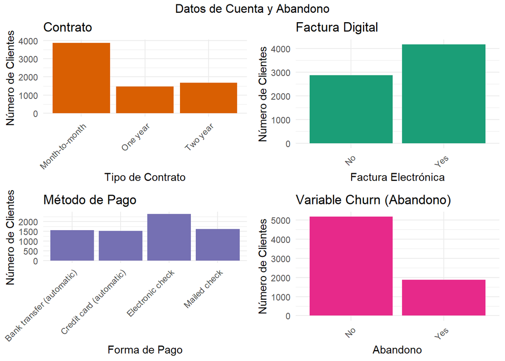

```r
p1 <- ggplot(clean_data, aes(x = Contract)) +
      geom_bar(fill = "#d95f02") + theme_minimal() +
      labs(title = "Contrato", x = "Tipo de Contrato", y = "Número de Clientes") +
      theme(axis.text.x = element_text(angle = 45, hjust = 1))

p2 <- ggplot(clean_data, aes(x = PaperlessBilling)) +
      geom_bar(fill = "#1b9e77") + theme_minimal() +
      labs(title = "Factura Digital", x = "Factura Electrónica", y = "Número de Clientes") +
      theme(axis.text.x = element_text(angle = 45, hjust = 1))

p3 <- ggplot(clean_data, aes(x = PaymentMethod)) +
      geom_bar(fill = "#7570b3") + theme_minimal() +
      labs(title = "Método de Pago", x = "Forma de Pago", y = "Número de Clientes") +
      theme(axis.text.x = element_text(angle = 45, hjust = 1))

p4 <- ggplot(clean_data, aes(x = Churn)) +
      geom_bar(fill = "#e7298a") + theme_minimal() +
      labs(title = "Variable Churn (Abandono)", x = "Abandono", y = "Número de Clientes") +
      theme(axis.text.x = element_text(angle = 45, hjust = 1))

grid.arrange(p1, p2, p3, p4, ncol = 2, top = "Datos de Cuenta y Abandono")
```

#### 2.2 Histogramas para las variables cuantitativas

Dado que son variables numericas, nos resulta mas interesnate hacer uso de los histogramas. Realizaremos todas en un único bloque de gráficos.

En este caso disponemos de 3 variables cuantitativas:

`tenure` `MonthlyCharges` `TotalCharges`

[figure not shown]

```r
h1 <- ggplot(clean_data, aes(x = tenure)) +
      geom_histogram(bins = 30, fill = "#440154", color = "white") +
      theme_minimal() + labs(title = "Meses en la compañía (Tenure)", x = "Meses", y = "Frecuencia") +
      theme(axis.text.x = element_text(angle = 45, hjust = 1))

h2 <- ggplot(clean_data, aes(x = MonthlyCharges)) +
      geom_histogram(bins = 30, fill = "#21908C", color = "white") +
      theme_minimal() + labs(title = "Gasto Mensual", x = "Euros/Mes", y = "Frecuencia") +
      theme(axis.text.x = element_text(angle = 45, hjust = 1))

h3 <- ggplot(clean_data, aes(x = TotalCharges)) +
      geom_histogram(bins = 30, fill = "#FDE725", color = "darkgrey") +
      theme_minimal() + labs(title = "Gasto Total", x = "Euros Totales", y = "Frecuencia") +
      theme(axis.text.x = element_text(angle = 45, hjust = 1))

grid.arrange(h1, h2, h3, ncol = 3, top = "Distribución de Variables Cuantitativas")
```

## ————————————————————————————–

## Apartado 3 – Diagramas e histogramas en función del Churn

En este caso utilizaremos la variable `churn` como medida de diferenciación cromática en los gráficos.

Realizaremos la misma subsidivision de antes:

3.1 Diagramas de frecuencia 3.1.1 Variables de perfil demográfico 3.1.2 Variables de servicios contratados para líneas móviles 3.1.3 Variables de servicios contratados para internet 3.1.4 Variables de servicios contratados para Smart Tv 3.1.5 Variables de cuentas, pagos y abandonos

3.2 Histogramas para las variables cuantitativas

##### 3.1.1 Variables de Perfil Demografico

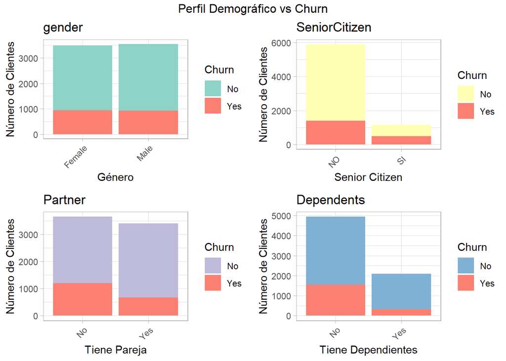

```r
d1_c <- ggplot(clean_data, aes(x = gender, fill = Churn)) +
        geom_bar() + scale_fill_manual(values = c("#8dd3c7", "#fb8072")) + theme_light() +
        labs(title = "gender", x = "Género", y = "Número de Clientes") +
        theme(axis.text.x = element_text(angle = 45, hjust = 1))

d2_c <- ggplot(clean_data, aes(x = SeniorCitizen, fill = Churn)) +
        geom_bar() + scale_fill_manual(values = c("#ffffb3", "#fb8072")) + theme_light() +
        labs(title = "SeniorCitizen", x = "Senior Citizen", y = "Número de Clientes") +
        theme(axis.text.x = element_text(angle = 45, hjust = 1))

d3_c <- ggplot(clean_data, aes(x = Partner, fill = Churn)) +
        geom_bar() + scale_fill_manual(values = c("#bebada", "#fb8072")) + theme_light() +
        labs(title = "Partner", x = "Tiene Pareja", y = "Número de Clientes") +
        theme(axis.text.x = element_text(angle = 45, hjust = 1))

d4_c <- ggplot(clean_data, aes(x = Dependents, fill = Churn)) +
        geom_bar() + scale_fill_manual(values = c("#80b1d3", "#fb8072")) + theme_light() +
        labs(title = "Dependents", x = "Tiene Dependientes", y = "Número de Clientes") +
        theme(axis.text.x = element_text(angle = 45, hjust = 1))

grid.arrange(d1_c, d2_c, d3_c, d4_c, ncol = 2, top = "Perfil Demográfico vs Churn")
```

##### 3.1.2 Variables de Servicios Contratados para líneas móviles

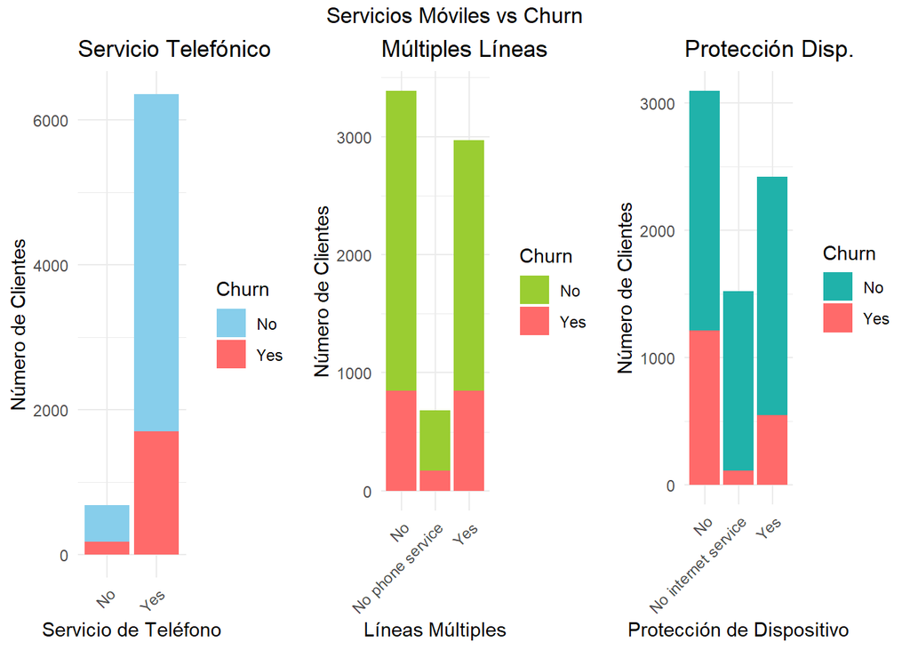

```r
s1_c <- ggplot(clean_data, aes(x = PhoneService, fill = Churn)) +
        geom_bar() + scale_fill_manual(values = c("skyblue", "indianred1")) + theme_minimal() +
        labs(title = "Servicio Telefónico", x = "Servicio de Teléfono", y = "Número de Clientes") +
        theme(axis.text.x = element_text(angle = 45, hjust = 1))

s2_c <- ggplot(clean_data, aes(x = MultipleLines, fill = Churn)) +
        geom_bar() + scale_fill_manual(values = c("olivedrab3", "indianred1")) + theme_minimal() +
        labs(title = "Múltiples Líneas", x = "Líneas Múltiples", y = "Número de Clientes") +
        theme(axis.text.x = element_text(angle = 45, hjust = 1))

s6_c <- ggplot(clean_data, aes(x = DeviceProtection, fill = Churn)) +
        geom_bar() + scale_fill_manual(values = c("lightseagreen", "indianred1")) + theme_minimal() +
        labs(title = "Protección Disp.", x = "Protección de Dispositivo", y = "Número de Clientes") +
        theme(axis.text.x = element_text(angle = 45, hjust = 1))

grid.arrange(s1_c, s2_c, s6_c, ncol = 3, top = "Servicios Móviles vs Churn")
```

##### 3.1.3 Variables de Servicios Contratados para Internet

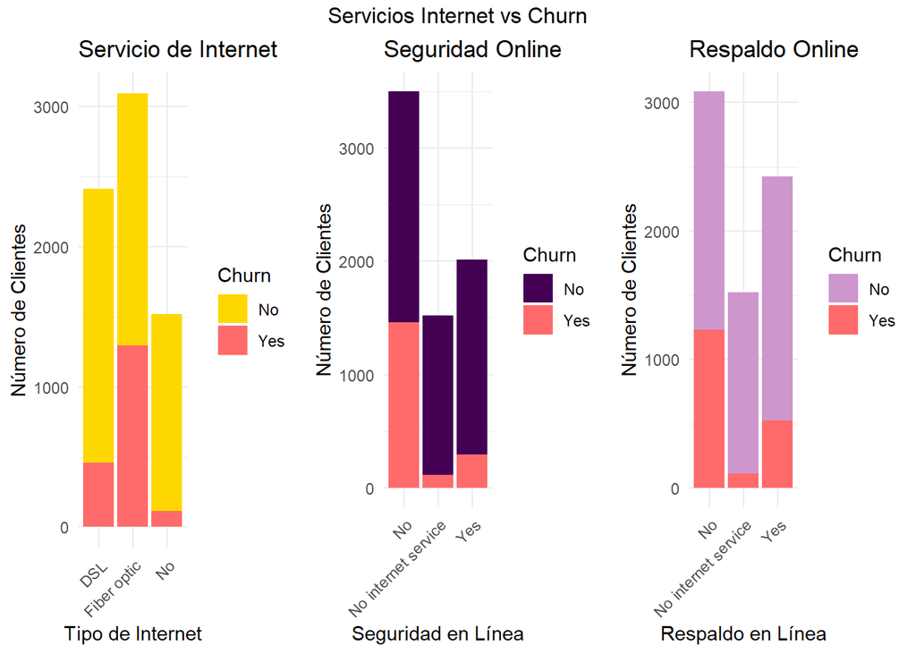

```r
s3_c <- ggplot(clean_data, aes(x = InternetService, fill = Churn)) +
        geom_bar() + scale_fill_manual(values = c("gold", "indianred1")) + theme_minimal() +
        labs(title = "Servicio de Internet", x = "Tipo de Internet", y = "Número de Clientes") +
        theme(axis.text.x = element_text(angle = 45, hjust = 1))

s4_c <- ggplot(clean_data, aes(x = OnlineSecurity, fill = Churn)) +
        geom_bar() + scale_fill_manual(values = c("#440154", "indianred1")) + theme_minimal() +
        labs(title = "Seguridad Online", x = "Seguridad en Línea", y = "Número de Clientes") +
        theme(axis.text.x = element_text(angle = 45, hjust = 1))

s5_c <- ggplot(clean_data, aes(x = OnlineBackup, fill = Churn)) +
        geom_bar() + scale_fill_manual(values = c("plum3", "indianred1")) + theme_minimal() +
        labs(title = "Respaldo Online", x = "Respaldo en Línea", y = "Número de Clientes") +
        theme(axis.text.x = element_text(angle = 45, hjust = 1))

grid.arrange(s3_c, s4_c, s5_c, ncol = 3, top = "Servicios Internet vs Churn")
```

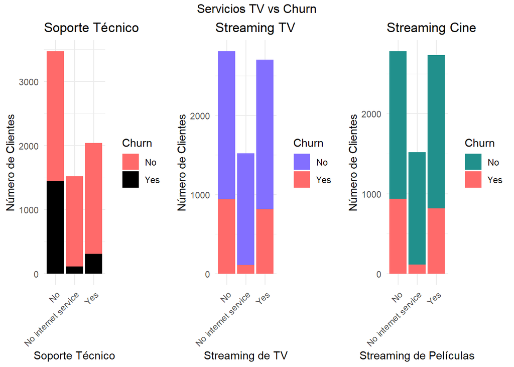

```r
s7_c <- ggplot(clean_data, aes(x = TechSupport, fill = Churn)) +
        geom_bar() + scale_fill_manual(values = c("indianred1", "black")) + theme_minimal() +
        labs(title = "Soporte Técnico", x = "Soporte Técnico", y = "Número de Clientes") +
        theme(axis.text.x = element_text(angle = 45, hjust = 1))

s8_c <- ggplot(clean_data, aes(x = StreamingTV, fill = Churn)) +
        geom_bar() + scale_fill_manual(values = c("slateblue1", "indianred1")) + theme_minimal() +
        labs(title = "Streaming TV", x = "Streaming de TV", y = "Número de Clientes") +
        theme(axis.text.x = element_text(angle = 45, hjust = 1))

s9_c <- ggplot(clean_data, aes(x = StreamingMovies, fill = Churn)) +
        geom_bar() + scale_fill_manual(values = c("#21908C", "indianred1")) + theme_minimal() +
        labs(title = "Streaming Cine", x = "Streaming de Películas", y = "Número de Clientes") +
        theme(axis.text.x = element_text(angle = 45, hjust = 1))

grid.arrange(s7_c, s8_c, s9_c, ncol = 3, top = "Servicios TV vs Churn")
```

##### 3.1.4 Variables de cuentas y pagos.

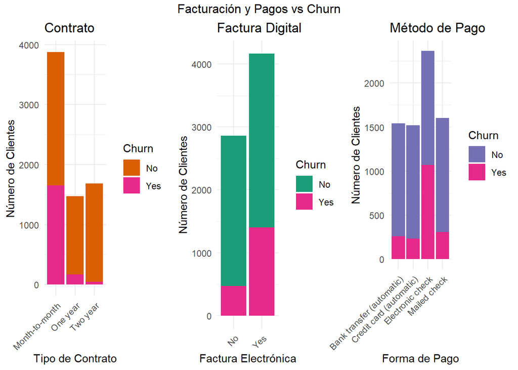

```r
p1_c <- ggplot(clean_data, aes(x = Contract, fill = Churn)) +
        geom_bar() + scale_fill_manual(values = c("#d95f02", "#e7298a")) + theme_minimal() +
        labs(title = "Contrato", x = "Tipo de Contrato", y = "Número de Clientes") +
        theme(axis.text.x = element_text(angle = 45, hjust = 1))

p2_c <- ggplot(clean_data, aes(x = PaperlessBilling, fill = Churn)) +
        geom_bar() + scale_fill_manual(values = c("#1b9e77", "#e7298a")) + theme_minimal() +
        labs(title = "Factura Digital", x = "Factura Electrónica", y = "Número de Clientes") +
        theme(axis.text.x = element_text(angle = 45, hjust = 1))

p3_c <- ggplot(clean_data, aes(x = PaymentMethod, fill = Churn)) +
        geom_bar() + scale_fill_manual(values = c("#7570b3", "#e7298a")) + theme_minimal() +
        labs(title = "Método de Pago", x = "Forma de Pago", y = "Número de Clientes") +
        theme(axis.text.x = element_text(angle = 45, hjust = 1))

grid.arrange(p1_c, p2_c, p3_c, ncol = 3, top = "Facturación y Pagos vs Churn")
```

##### 3.2 Histogramas para las variables cuantitativas

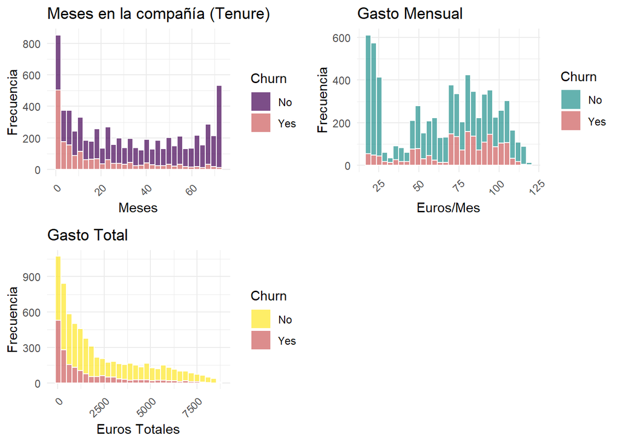

```r
h1_c <- ggplot(clean_data, aes(x = tenure, fill = Churn)) +
        geom_histogram(bins = 30, color = "white", alpha = 0.7) +
        scale_fill_manual(values = c("#440154", "#CD5C5C")) + theme_minimal() +
        labs(title = "Meses en la compañía (Tenure)", x = "Meses", y = "Frecuencia") +
        theme(axis.text.x = element_text(angle = 45, hjust = 1))

h2_c <- ggplot(clean_data, aes(x = MonthlyCharges, fill = Churn)) +
        geom_histogram(bins = 30, color = "white", alpha = 0.7) +
        scale_fill_manual(values = c("#21908C", "#CD5C5C")) + theme_minimal() +
        labs(title = "Gasto Mensual", x = "Euros/Mes", y = "Frecuencia") +
        theme(axis.text.x = element_text(angle = 45, hjust = 1))

h3_c <- ggplot(clean_data, aes(x = TotalCharges, fill = Churn)) +
        geom_histogram(bins = 30, color = "white", alpha = 0.7) +
        scale_fill_manual(values = c("#FDE725", "#CD5C5C")) + theme_minimal() +
        labs(title = "Gasto Total", x = "Euros Totales", y = "Frecuencia") +
        theme(axis.text.x = element_text(angle = 45, hjust = 1))

grid.arrange(h1_c, h2_c, h3_c, ncol = 2)
```

## ————————————————————————————–

## Apartado 4 – Boxplots

En este apartado nos piden **realizar boxplots para cada una de las variables cualitativas**.

Nos piden realizarla en funcion de la variable `MonthlyCharges`

Para seguir con el esquema de graficos utilizare las anteriores distribuciones:

4.1 Variables de perfil demográfico 4.2 Variables de servicios contratados para líneas móviles 4.3 Variables de servicios contratados para internet 4.4 Variables de servicios contratados para Smart Tv 4.5 Variables de cuentas, pagos y abandonos

##### 4.1 Variables de perfil demográfico

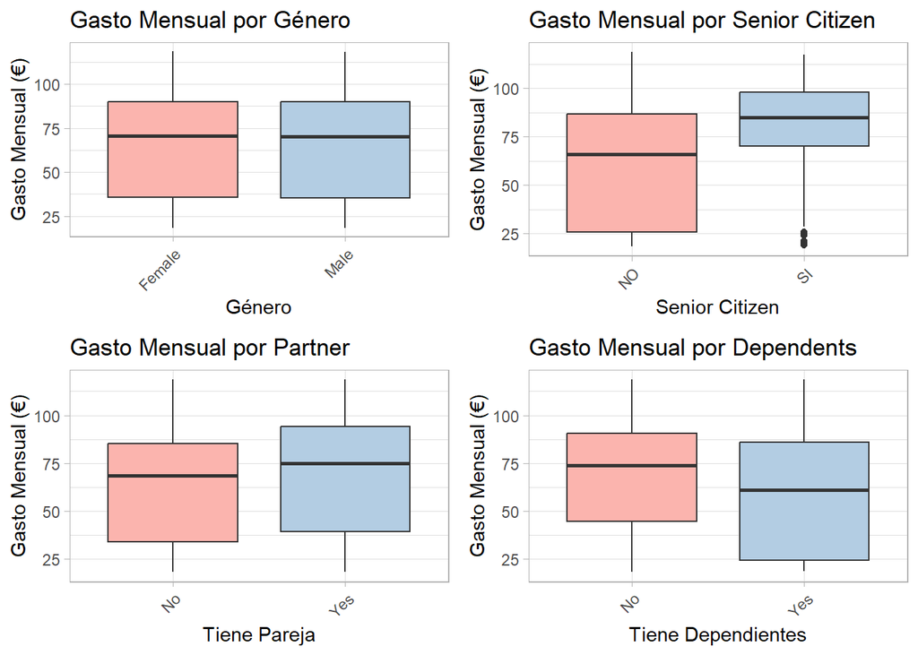

```r
b_d1 <- ggplot(clean_data, aes(x = gender, y = MonthlyCharges, fill = gender)) +
        geom_boxplot() + theme_light() + scale_fill_brewer(palette = "Pastel1") +
        labs(title = "Gasto Mensual por Género", x = "Género", y = "Gasto Mensual (€)") +
        theme(axis.text.x = element_text(angle = 45, hjust = 1), legend.position = "none")

b_d2 <- ggplot(clean_data, aes(x = SeniorCitizen, y = MonthlyCharges, fill = SeniorCitizen)) +
        geom_boxplot() + theme_light() + scale_fill_brewer(palette = "Pastel1") +
        labs(title = "Gasto Mensual por Senior Citizen", x = "Senior Citizen", y = "Gasto Mensual (€)") +
        theme(axis.text.x = element_text(angle = 45, hjust = 1), legend.position = "none")

b_d3 <- ggplot(clean_data, aes(x = Partner, y = MonthlyCharges, fill = Partner)) +
        geom_boxplot() + theme_light() + scale_fill_brewer(palette = "Pastel1") +
        labs(title = "Gasto Mensual por Partner", x = "Tiene Pareja", y = "Gasto Mensual (€)") +
        theme(axis.text.x = element_text(angle = 45, hjust = 1), legend.position = "none")

b_d4 <- ggplot(clean_data, aes(x = Dependents, y = MonthlyCharges, fill = Dependents)) +
        geom_boxplot() + theme_light() + scale_fill_brewer(palette = "Pastel1") +
        labs(title = "Gasto Mensual por Dependents", x = "Tiene Dependientes", y = "Gasto Mensual (€)") +
        theme(axis.text.x = element_text(angle = 45, hjust = 1), legend.position = "none")

grid.arrange(b_d1, b_d2, b_d3, b_d4, ncol = 2)
```

##### 4.2 Variables de servicios contratados para líneas móviles

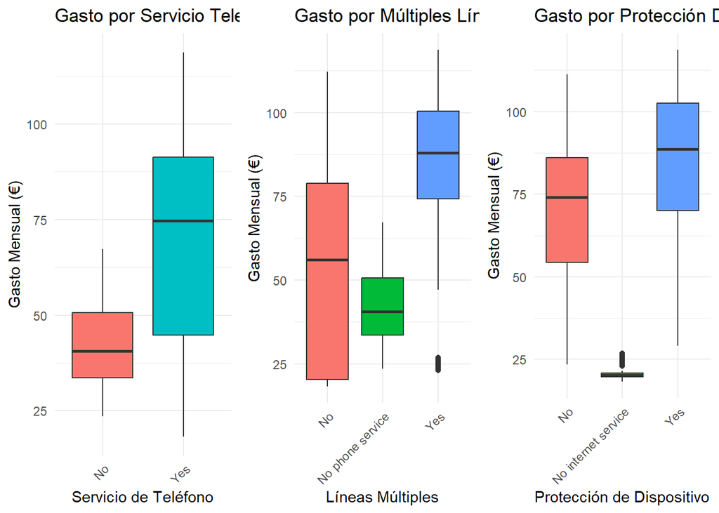

```r
b_s1 <- ggplot(clean_data, aes(x = PhoneService, y = MonthlyCharges, fill = PhoneService)) +
        geom_boxplot() + theme_minimal() +
        labs(title = "Gasto por Servicio Telefónico", x = "Servicio de Teléfono", y = "Gasto Mensual (€)") +
        theme(axis.text.x = element_text(angle = 45, hjust = 1), legend.position = "none")

b_s2 <- ggplot(clean_data, aes(x = MultipleLines, y = MonthlyCharges, fill = MultipleLines)) +
        geom_boxplot() + theme_minimal() +
        labs(title = "Gasto por Múltiples Líneas", x = "Líneas Múltiples", y = "Gasto Mensual (€)") +
        theme(axis.text.x = element_text(angle = 45, hjust = 1), legend.position = "none")

b_s6 <- ggplot(clean_data, aes(x = DeviceProtection, y = MonthlyCharges, fill = DeviceProtection)) +
        geom_boxplot() + theme_minimal() +
        labs(title = "Gasto por Protección Disp.", x = "Protección de Dispositivo", y = "Gasto Mensual (€)") +
        theme(axis.text.x = element_text(angle = 45, hjust = 1), legend.position = "none")

grid.arrange(b_s1, b_s2, b_s6, ncol = 3)
```

##### 4.3 Variables de servicios contratados para internet

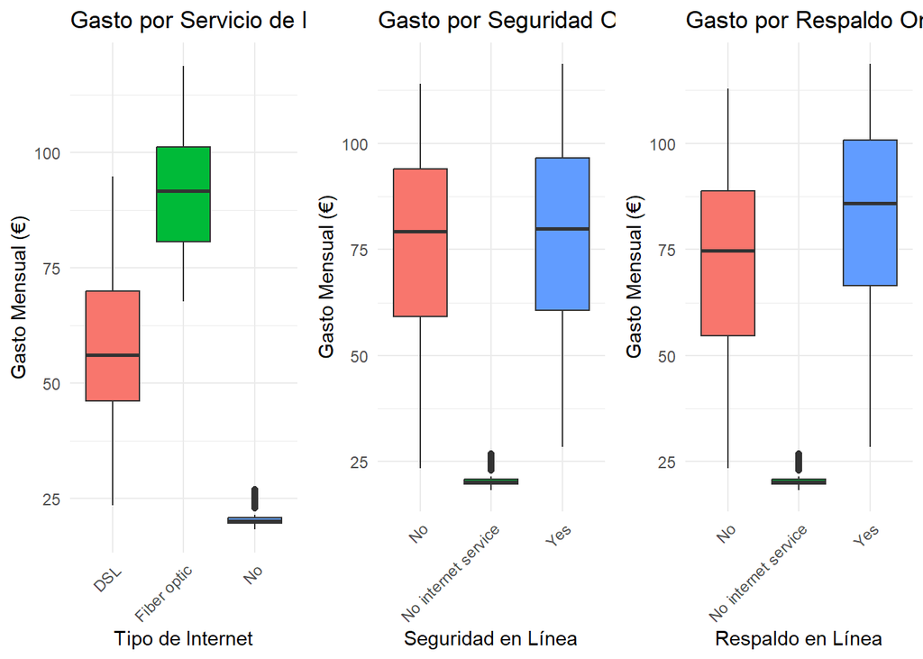

```r
b_s3 <- ggplot(clean_data, aes(x = InternetService, y = MonthlyCharges, fill = InternetService)) +
        geom_boxplot() + theme_minimal() +
        labs(title = "Gasto por Servicio de Internet", x = "Tipo de Internet", y = "Gasto Mensual (€)") +
        theme(axis.text.x = element_text(angle = 45, hjust = 1), legend.position = "none")

b_s4 <- ggplot(clean_data, aes(x = OnlineSecurity, y = MonthlyCharges, fill = OnlineSecurity)) +
        geom_boxplot() + theme_minimal() +
        labs(title = "Gasto por Seguridad Online", x = "Seguridad en Línea", y = "Gasto Mensual (€)") +
        theme(axis.text.x = element_text(angle = 45, hjust = 1), legend.position = "none")

b_s5 <- ggplot(clean_data, aes(x = OnlineBackup, y = MonthlyCharges, fill = OnlineBackup)) +
        geom_boxplot() + theme_minimal() +
        labs(title = "Gasto por Respaldo Online", x = "Respaldo en Línea", y = "Gasto Mensual (€)") +
        theme(axis.text.x = element_text(angle = 45, hjust = 1), legend.position = "none")

grid.arrange(b_s3, b_s4, b_s5, ncol = 3)
```

##### 4.4 Variables de servicios contratados para Smart Tv

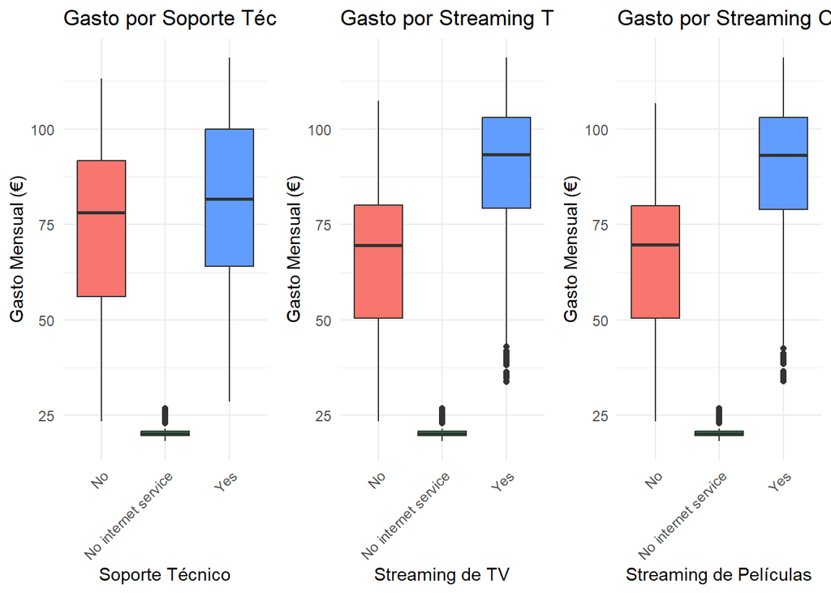

```r
b_s7 <- ggplot(clean_data, aes(x = TechSupport, y = MonthlyCharges, fill = TechSupport)) +
        geom_boxplot() + theme_minimal() +
        labs(title = "Gasto por Soporte Técnico", x = "Soporte Técnico", y = "Gasto Mensual (€)") +
        theme(axis.text.x = element_text(angle = 45, hjust = 1), legend.position = "none")

b_s8 <- ggplot(clean_data, aes(x = StreamingTV, y = MonthlyCharges, fill = StreamingTV)) +
        geom_boxplot() + theme_minimal() +
        labs(title = "Gasto por Streaming TV", x = "Streaming de TV", y = "Gasto Mensual (€)") +
        theme(axis.text.x = element_text(angle = 45, hjust = 1), legend.position = "none")

b_s9 <- ggplot(clean_data, aes(x = StreamingMovies, y = MonthlyCharges, fill = StreamingMovies)) +
        geom_boxplot() + theme_minimal() +
        labs(title = "Gasto por Streaming Cine", x = "Streaming de Películas", y = "Gasto Mensual (€)") +
        theme(axis.text.x = element_text(angle = 45, hjust = 1), legend.position = "none")

grid.arrange(b_s7, b_s8, b_s9, ncol = 3)
```

##### 4.5 Variables de cuentas, pagos y abandonos

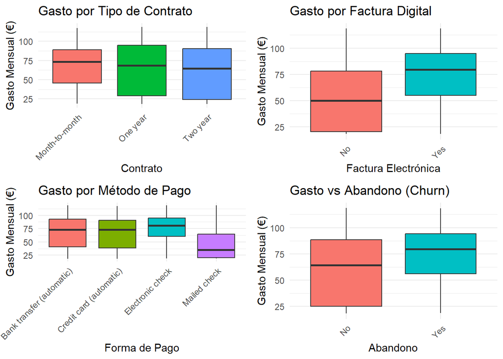

```r
b_p1 <- ggplot(clean_data, aes(x = Contract, y = MonthlyCharges, fill = Contract)) +
        geom_boxplot() + theme_minimal() +
        labs(title = "Gasto por Tipo de Contrato", x = "Contrato", y = "Gasto Mensual (€)") +
        theme(axis.text.x = element_text(angle = 45, hjust = 1), legend.position = "none")

b_p2 <- ggplot(clean_data, aes(x = PaperlessBilling, y = MonthlyCharges, fill = PaperlessBilling)) +
        geom_boxplot() + theme_minimal() +
        labs(title = "Gasto por Factura Digital", x = "Factura Electrónica", y = "Gasto Mensual (€)") +
        theme(axis.text.x = element_text(angle = 45, hjust = 1), legend.position = "none")

b_p3 <- ggplot(clean_data, aes(x = PaymentMethod, y = MonthlyCharges, fill = PaymentMethod)) +
        geom_boxplot() + theme_minimal() +
        labs(title = "Gasto por Método de Pago", x = "Forma de Pago", y = "Gasto Mensual (€)") +
        theme(axis.text.x = element_text(angle = 45, hjust = 1), legend.position = "none")

b_p4 <- ggplot(clean_data, aes(x = Churn, y = MonthlyCharges, fill = Churn)) +
        geom_boxplot() + theme_minimal() +
        labs(title = "Gasto vs Abandono (Churn)", x = "Abandono", y = "Gasto Mensual (€)") +
        theme(axis.text.x = element_text(angle = 45, hjust = 1), legend.position = "none")

grid.arrange(b_p1, b_p2, b_p3, b_p4, ncol = 2)
```

## ————————————————————————————–

## Apartado 5 – Gráfico de dispersión

En este apartado realizaremos graficos de dispersion con el fin de encontrar **correlaciones entre las variables cuantitativas**. Utilizaremos la matriz de correlacion que nos permite ver tanto los diagaramas, como la distribucion y su coeficiente de correlacion.

Teniendo en cuenta que tenemos 3 variables, las correlaciones que nos van a salir seran:

`Tenure` vs `TotalCharges` `MonthlyCharges` vs `TotalCharges` `Tenure` vs `MonthlyCharges`

Representaremos los 3 graficos juntos

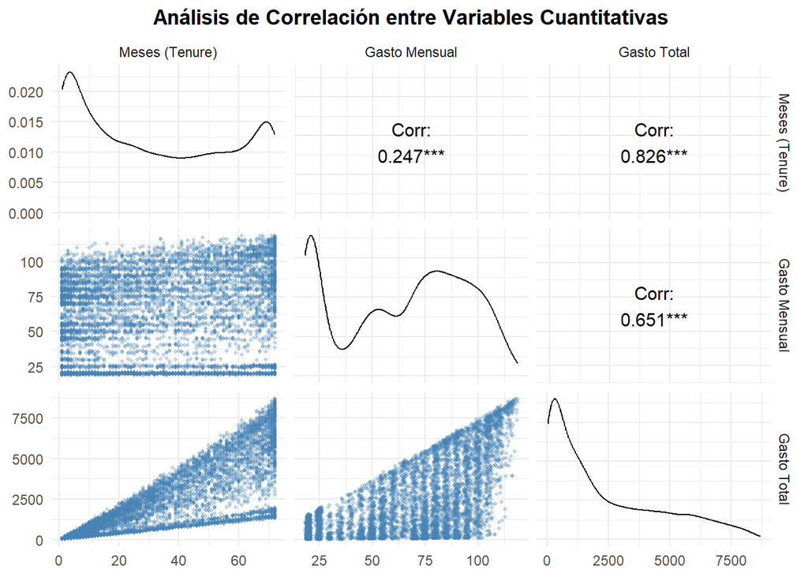

```r
vars_cuantitativas <- clean_data[, c("tenure", "MonthlyCharges", "TotalCharges")]

ggpairs(vars_cuantitativas,
        title = "Análisis de Correlación entre Variables Cuantitativas",
        columnLabels = c("Meses (Tenure)", "Gasto Mensual", "Gasto Total"),
        lower = list(continuous = wrap("points", alpha = 0.3, size = 0.8, color = "#4682B4")),
        upper = list(continuous = wrap("cor", size = 4, color = "black"))) +
  theme_minimal() +
  theme(plot.title = element_text(hjust = 0.5, face = "bold"))
```

## ————————————————————————————–

# EJERCICIO 2 – MODELO DE REGRESIÓN

Para generar un modelo de regresion, el primer paso sera dividir los datos **en datos de entrenamiento y datos de test**

Segun nos indican en el ejercicio cumpliremos esto:

- El subconjunto de datos de entrenamiento se llamara `churn_train1`
  - Contendra las 5000 primeras filas del conjunto `clean_data`
- El subconjunto de datos de test se llamara `churn_test1`
  - Contendra el resto de filas del conjunto `clean_data` desde la 5001

```r
churn_train1 <- clean_data[1:5000, ]

churn_test1 <- clean_data[5001:nrow(clean_data), ]
```

## ————————————————————————————–

## Apartado 1 - Diseño del modelo de regresión

**Crearemos un modelo de regresion multilineal, llamado, *lmodel***, cumpliendo estas normas:

- Lo ajustaremos con el subconjunto `churn_train1`
- Utilizaremos los datos del conjunto `clean_data`
- La variable objetivo sera `MonthlyCharges`
- Las variables predictoras seran todas a excepcion de `TotalCharges`y `Churn`

```r
Imodel <- lm(MonthlyCharges ~ . - TotalCharges - Churn, data = churn_train1)
```

Con el modelo entrenado, veremos **un resumen de los datos con *summary()*** para responder a estas preguntas:

1. *¿Cuáles son las variables/coeficientes que a un nivel de significancia del 95% podemos concluir que son “no nulos”?*
2. *A partir del valor de los coeficientes, ¿cuál sería la estimación de los diferentes servicios: teléfono, DSL, Fibra, seguridad, TV, ¿… ?*

```r
summary(Imodel)
```

```
##
## Call:
## lm(formula = MonthlyCharges ~ . - TotalCharges - Churn, data = churn_train1)
##
## Residuals:
##     Min      1Q  Median      3Q     Max
## -4.1927 -0.5992  0.0026  0.6025  4.8593
##
## Coefficients: (7 not defined because of singularities)
##                                        Estimate Std. Error  t value Pr(>|t|)
## (Intercept)                           2.493e+01  6.918e-02  360.357   <2e-16
## genderMale                            7.461e-03  2.886e-02    0.259    0.796
## SeniorCitizenSI                       1.183e-03  4.200e-02    0.028    0.978
## PartnerYes                           -1.705e-02  3.518e-02   -0.485    0.628
## DependentsYes                         3.445e-02  3.710e-02    0.928    0.353
## tenure                                4.699e-04  1.002e-03    0.469    0.639
## PhoneServiceYes                       2.007e+01  5.755e-02  348.781   <2e-16
## MultipleLinesNo phone service                NA         NA       NA       NA
## MultipleLinesYes                      5.005e+00  3.460e-02  144.665   <2e-16
## InternetServiceFiber optic            2.498e+01  4.087e-02  611.186   <2e-16
## InternetServiceNo                    -2.505e+01  5.693e-02 -439.966   <2e-16
## OnlineSecurityNo internet service            NA         NA       NA       NA
## OnlineSecurityYes                     4.995e+00  3.811e-02  131.085   <2e-16
## OnlineBackupNo internet service              NA         NA       NA       NA
## OnlineBackupYes                       5.010e+00  3.576e-02  140.096   <2e-16
## DeviceProtectionNo internet service          NA         NA       NA       NA
## DeviceProtectionYes                   5.024e+00  3.700e-02  135.786   <2e-16
## TechSupportNo internet service               NA         NA       NA       NA
## TechSupportYes                        5.025e+00  3.899e-02  128.865   <2e-16
## StreamingTVNo internet service               NA         NA       NA       NA
## StreamingTVYes                        9.944e+00  3.805e-02  261.318   <2e-16
## StreamingMoviesNo internet service           NA         NA       NA       NA
## StreamingMoviesYes                    9.986e+00  3.798e-02  262.944   <2e-16
## ContractOne year                      7.533e-03  4.540e-02    0.166    0.868
## ContractTwo year                     -1.692e-04  5.533e-02   -0.003    0.998
## PaperlessBillingYes                  -1.526e-03  3.233e-02   -0.047    0.962
## PaymentMethodCredit card (automatic) -6.455e-02  4.352e-02   -1.483    0.138
## PaymentMethodElectronic check        -1.711e-02  4.284e-02   -0.399    0.690
## PaymentMethodMailed check            -1.150e-02  4.676e-02   -0.246    0.806
##
```

[output cut: 20 more lines]

```
## StreamingTVYes                       ***
## StreamingMoviesNo internet service
## StreamingMoviesYes                   ***
## ContractOne year
## ContractTwo year
## PaperlessBillingYes
## PaymentMethodCredit card (automatic)
## PaymentMethodElectronic check
## PaymentMethodMailed check
## ---
## Signif. codes:  0 '***' 0.001 '**' 0.01 '*' 0.05 '.' 0.1 ' ' 1
##
## Residual standard error: 1.018 on 4978 degrees of freedom
## Multiple R-squared:  0.9989, Adjusted R-squared:  0.9989
## F-statistic: 2.081e+05 on 21 and 4978 DF,  p-value: < 2.2e-16
```

##### Respuesta 1.

`¿Cuáles son las variables/coeficientes que a un nivel de significancia del 95% podemos concluir que son “no nulos”?`

Teniendo en cuenta la significancia, estas son las variables que cumplen:

[output not shown]

##### Respuesta 2.

`A partir del valor de los coeficientes, ¿cuál sería la estimación de los diferentes servicios: teléfono, DSL, Fibra, seguridad, TV, ¿… ?`

Teniendo en cuenta la significancia, estas son las variables que cumplen:

[output not shown]

Por último voy a realizar **una prediccion sobre el conjunto de datos *churn_test1***, calcular la metrica de error *RMSE* y mostrar el resultado por pantalla.

```r
pred_model <- predict(Imodel, newdata = churn_test1)

rmse_valor <- sqrt(mean((churn_test1$MonthlyCharges - pred_model)^2))

cat("El error promedio (RMSE) del modelo es:", round(rmse_valor, 4), "€")
```

```
## El error promedio (RMSE) del modelo es: 1.0444 €
```

## ————————————————————————————–

# EJERCICIO 3 – MODELO DE CLASIFICACIÓN

En este ccaso vamos a crear un nuevo conjunto de datos llamado *clean_data2*, que nacera del *clean_data* pero eliminare la variable `TotalCharges`

```r
clean_data2 <- clean_data %>% select(-TotalCharges)
```

Vamos a **crear los subconjuntos de datos** que utilizaremos mas adelante para entrenar los modelos de clasificacion

Cumpliran estas premisas:

```r
churn_train2 <- clean_data2[1:5000, ]
churn_test2 <- clean_data2[5001:nrow(clean_data2), ]
```

## ————————————————————————————–

## Apartado 1 - Modelo de clasificación 1 (gmodel1)

Vamos a crear un modelo de clasificacion llamado *gmodel1* cumpliendo estas normas:

- Utilizaremos los datos del conjunto `clean_data2`
- La variable objetivo sera `Churn`
- Las variables predictoras seran todas

```r
gmodel1 <- glm(Churn ~ ., data = churn_train2, family = "binomial")
```

Ahora con el modelo creado **vamos a aplicarlo al subconjunto de datos *churn_test2*** para obtener la probabilidad de abandono de los clientes.

```r
prob_churn1 <- predict(gmodel1, newdata = churn_test2, type = "response")
```

Por Último, en base a esta probabilidad vamos a crear una variable llamada *churn_pred* que cumplira esto:

- el valor “Yes” si la predicción es mayor de 0.5
- el valor “NO” si la predicción es menor de 0.5

```r
churn_pred1 <- ifelse(prob_churn1 > 0.5, "Yes", "No")
churn_pred1 <- factor(churn_pred1, levels = c("No", "Yes"))
```

## ————————————————————————————–

Ahora vamos a crear una **matriz de confusion** en base al modelo y variable de la probabilidad de abandono, para dar respuesta a estas cuestiones:

1. La precisión global de la predicción ( accuracy )
2. El ratio de falsos positivos (FPR)
3. El ratio de falsos negativos (FNR)
4. El ratio de verdaderos positivos (TPR)

```r
matriz1 <- table(PREDICCIÓN = churn_pred1, REAL = churn_test2$Churn)
print(matriz1)
```

```
##           REAL
## PREDICCIÓN   No  Yes
##        No  1335  258
##        Yes  145  294
```

Ahora **extraemos los valores de la matriz** para pdoer dar respuesta a los diferentes parametros solicitados:

```r
TN1 <- matriz1[1,1]
FN1 <- matriz1[1,2]
FP1 <- matriz1[2,1]
TP1 <- matriz1[2,2]
```

##### 1. La precisión global de la predicción ( accuracy )

Lo calcularemos en base a esta formula:

`Precisión = (TP + TN) / (TP + TN + FP + FN)`

```r
accuracy1 <- (TP1 + TN1) / (TP1 + TN1 + FP1 + FN1)
print(accuracy1)
```

```
## [1] 0.8016732
```

##### 2. El ratio de falsos positivos (FPR)

Lo calcularemos en base a esta formula:

`FPR = FP / (FP + TN)`

```r
fpr1      <- FP1 / (FP1 + TN1)
print(fpr1)
```

```
## [1] 0.09797297
```

##### 3. El ratio de falsos negativos (FNR)

Lo calcularemos en base a esta formula:

`FNR = FN / (FN + TP)`

```r
fnr1      <- FN1 / (FN1 + TP1)
print(fnr1)
```

```
## [1] 0.4673913
```

##### 4. El ratio de verdaderos positivos (TPR)

Lo calcularemos en base a esta formula:

`TPR = TP / (TP + FN)`

```r
tpr1      <- TP1 / (TP1 + FN1)
print(tpr1)
```

```
## [1] 0.5326087
```

## ————————————————————————————–

## Apartado 1 - Modelo de clasificación 2

Vamos a crear un modelo de clasificacion llamado *gmodel2* cumpliendo estas normas:

- Utilizaremos los datos del conjunto `clean_data2`
- La variable objetivo sera `Churn`
- Las variables predictoras seran todas `Contract`, `Tenure`, `InternetService`

```r
gmodel2 <- glm(Churn ~ Contract + tenure + InternetService,
               data = churn_train2, family = "binomial")
```

Ahora con el modelo creado **vamos a aplicarlo al subconjunto de datos *churn_test2*** para obtener la probabilidad de abandono de los clientes.

```r
prob_churn2 <- predict(gmodel2, newdata = churn_test2, type = "response")
```

Por Último, en base a esta probabilidad vamos a crear una variable llamada *churn_pred2* que cumplira esto:

- el valor “Yes” si la predicción es mayor de 0.5
- el valor “NO” si la predicción es menor de 0.5

```r
churn_pred2 <- ifelse(prob_churn2 > 0.5, "Yes", "No")
churn_pred2 <- factor(churn_pred2, levels = c("No", "Yes"))
```

## ————————————————————————————–

Ahora vamos a crear una **matriz de confusion** en base al modelo y variable de la probabilidad de abandono, para dar respuesta a estas cuestiones:

1. La precisión global de la predicción ( accuracy )
2. El ratio de falsos positivos (FPR)
3. El ratio de falsos negativos (FNR)
4. El ratio de verdaderos positivos (TPR)

```r
matriz2 <- table(PREDICCIÓN = churn_pred2, REAL = churn_test2$Churn)
print(matriz2)
```

```
##           REAL
## PREDICCIÓN   No  Yes
##        No  1335  290
##        Yes  145  262
```

Ahora **extraemos los valores de la matriz** para pdoer dar respuesta a los diferentes parametros solicitados:

```r
TN2 <- matriz2[1,1]
FN2 <- matriz2[1,2]
FP2 <- matriz2[2,1]
TP2 <- matriz2[2,2]
```

##### 1. La precisión global de la predicción ( accuracy )

Lo calcularemos en base a esta formula:

`Precisión = (TP + TN) / (TP + TN + FP + FN)`

```r
accuracy2 <- (TP2 + TN2) / (TP2 + TN2 + FP2 + FN2)
print(accuracy2)
```

```
## [1] 0.7859252
```

##### 2. El ratio de falsos positivos (FPR)

Lo calcularemos en base a esta formula:

`FPR = FP / (FP + TN)`

```r
fpr2      <- FP2 / (FP2 + TN2)
print(fpr2)
```

```
## [1] 0.09797297
```

##### 3. El ratio de falsos negativos (FNR)

Lo calcularemos en base a esta formula:

`FNR = FN / (FN + TP)`

```r
fnr2      <- FN2 / (FN2 + TP2)
print(fnr2)
```

```
## [1] 0.5253623
```

##### 4. El ratio de verdaderos positivos (TPR)

Lo calcularemos en base a esta formula:

`TPR = TP / (TP + FN)`

```r
tpr2      <- TP2 / (TP2 + FN2)
print(tpr2)
```

```
## [1] 0.4746377
```

## ————————————————————————————–

### Comparacion y conclusiones entre ambos modelos de clasificación:

Esta es la tabla de los datos **comparando los parametros obtenidos de la matriz de confusion**

##### **gmodel1**

| Métrica de Evaluación | Valor obtenido |
| --- | --- |
| Accuracy (Precisión Global) | 80.17% |
| FPR (Falsos Positivos) | 9.80% |
| FNR (Falsos Negativos) | 46.74% |
| TPR (Verdaderos Positivos) | 53.26% |

##### **gmodel2**

| Métrica de Evaluación | Valor obtenido |
| --- | --- |
| Accuracy (Precisión Global) | 78.59% |
| FPR (Falsos Positivos) | 9.80% |
| FNR (Falsos Negativos) | 52.54% |
| TPR (Verdaderos Positivos) | 47.46% |

Algunas conclusiones que se pueden sacar:

1. Precisión Global (Accuracy): El gmodel1 es superior, logrando acertar en el 80.17% de los casos totales. Aunque ambos modelos están cerca del 80%, el gmodel1 tiene mas variables y clasifica mejor a los clientes.
2. Ratio de Falsos Positivos (FPR): Aquí hay un empate técnico (9.80%).
3. Ratio de Falsos Negativos (FNR): El gmodel1 tiene un error de omisión menor (46.74% frente al 52.54% del gmodel2). El gmodel2 tiene menos en cuenta las variables y su error puede significar no tener en cuenta el total de clientes con alta tasa de abandono, lo que podria implicar ser peor.
4. Ratio de Verdaderos Positivos (TPR / Sensibilidad): El gmodel1 detecta mejor el abandono real (53.26%).

##### **La conclusion es que el gmodel1 predice mejor como se van a comportar los clientes y es mas fiable**

## ————————————————————————————–

# EJERCICIO 4 – SIMULACIÓN DE CAMPAÑA

Ahora vamos a evaluar el rendimientto economico de una campaña de retencion de clientes, para lo que realizaremos un nuevo modelo de clasificacion llamado, *gmodel3*, cumpliremos estas normas:

- Ajustaremos el modelo con el conjunto de datos de entrenamiento `churn_train2`
- Utilizaremos los datos del conjunto `clean_data2`
- La variable objetivo sera `Churn`
- Las variables predictoras seran todas

```r
gmodel3 <- glm(Churn ~ ., data = churn_train2, family = "binomial")
```

Ahora realizaremos **una prediccion sobre el subconjunto de datos de testeo `churn_test2`** para obtener la probabilidad de abandono de los clientes

```r
prob_test <- predict(gmodel3, newdata = churn_test2, type = "response")
```

Una vez obtenida la probabilidad de abandono de los clientes **creamos una variable `churn_pred`** que cumpla estas normas:

- el valor “Yes” si la predicción es mayor de 0.5
- el valor “NO” si la predicción es menor de 0.5

```r
churn_pred <- ifelse(prob_test > 0.5, "Yes", "No")

churn_pred <- factor(churn_pred, levels = c("No", "Yes"))
```

Con esta informacion **vamos a realizar una matriz de confusion con los resultados obtenidos** del modelo gmodel3

```r
matriz_ej4 <- table(PREDICCIÓN = churn_pred, REAL = churn_test2$Churn)

print(matriz_ej4)
```

```
##           REAL
## PREDICCIÓN   No  Yes
##        No  1335  258
##        Yes  145  294
```

## ————————————————————————————–

#### Parametros a tener en cuenta para los Escenarios

Una vez listos los modelos vamos a evaluar los rendimientos de las campañas en 2 escenarios diferenciados.

Para ello vamos a tener en cuenta ciertos parametros:

- A los clientes clasificados por el modelo como *“Churners”* se les ofrecerá un teléfono de regalo a cambio de que firmen un contrato de permanencia de un año. **El coste del teléfono se denominará *CT O I.***
- **Los clientes aceptarán el trato con una probabilidad *AR***
- El beneficio asociado a la retención de un cliente lo estimamos como el consumo medio anual de un cliente menos el coste de gestión (uso de infraestructura, facturación, atención al cliente, …).
- Se estima que **la pérdida de un cliente que abandona la compañía es igual al retorno *R* que genera la retención, es decir 500€.**

#### Calculos que se realizaran en los Escenarios

A parte de los parametros, habra ciertos calculos asociados que se haran a partir de estas variables y que nos permitiran determinar que escenario es mas propicio. Sacaremos conclusiones en base a estos calculos.

1. **El rendimiento se deberá calcular en diferentes umbrales de clasificación** siguiendo esta formula y reglas:

`up = (0, 0.1, 0.2, 0.3, 0.4, 0.5, 0.6, 0.7, 0.8, 0.9 y 1)`

- pred_churn = “Yes” si la probabilidad > up
- pred_churn = “No” en caso contrario

*El objetivo del ejercicio será encontrar el umbral óptimo en el que se obtiene un mayor rendimiento para la campaña.*

*Para cada umbral de probabilidad, se deberá calcular a partir de la probabilidad del modelo la variable `churn_pred` y obtener la matriz de confusión, de forma que sea posible estimar el beneficio de la campaña*

2. **el beneficio de la campaña** se calculara con la siguiente formula:

`Beneficio = Resultado con campaña – Resultado sin campaña`

3. **El resultado con campaña** se calculara con la siguiente formula:

`Resultado con campaña = -FP * AR * I – TP * AR * I – TP * (1 – AR) * R – FN * R`

4. **El resultado sin campaña** se calculara con la siguiente formula:

`Resultado sin campaña: - (FN + TP) * R`

Los terminos para calcular los resultados, **se obtienen de la matriz de confusion y son estos**:

- *FP (Falsos Positivos)*: Clientes que el modelo identifica erróneamente como “fugados”, pero que en realidad no pensaban irse.
- *TP (Verdaderos Positivos*): Clientes que el modelo identifica correctamente como personas que van a abandonar la compañía.
- *FN (Falsos Negativos)*: Clientes que el modelo clasifica como “fieles”, pero que acaban marchándose sin que les hayamos ofrecido nada.

Con todo esto ya estamos en disposicion para:

1. **Preparar una funcion que podamos hacer para obtener los parametros y realizar los caluclos pertinentes**
2. **Realizar la simulacion de los escenarios cambiando las variables**

## ————————————————————————————–

#### 1. Definimos la funcion para simular la rentabilidad que utilizaremos en los 2 Escenarios

Con esta funcion lo que nos permitira podremos iterar **la obtencion de todos los parametros y calculos para cada umbral (up)**

De este modo sobre sera necesario cambiar los valores de ciertos parametros para obtener un valor resultado

```r
# Definimos la función
simular_rentabilidad <- function(umbral, coste_tel, prob_aceptacion) {

  # 1. Clasificación según umbral (up) solicitado
  pred_churn <- ifelse(prob_test > umbral, "Yes", "No")
  pred_churn <- factor(pred_churn, levels = c("No", "Yes"))

  # 2. Matriz de confusión para este umbral
  m <- table(PREDICCIÓN = pred_churn, REAL = churn_test2$Churn)

  # 3. Extraer valores (TP, FP, FN)
  FN <- if("No" %in% rownames(m) & "Yes" %in% colnames(m)) m["No", "Yes"] else 0
  FP <- if("Yes" %in% rownames(m) & "No" %in% colnames(m)) m["Yes", "No"] else 0
  TP <- if("Yes" %in% rownames(m) & "Yes" %in% colnames(m)) m["Yes", "Yes"] else 0

  # 4. Parámetros fijos
  R <- 500 # Retorno por cliente

  # 5. Aplicar fórmulas de resultados

    # 5.1 Resultado con campaña
  res_con <- -FP * prob_aceptacion * coste_tel -
              TP * prob_aceptacion * coste_tel -
              TP * (1 - prob_aceptacion) * R -
              FN * R

    # 5.2 Resultado sin camapaña
  res_sin <- -(FN + TP) * R

  # 6. Beneficio neto
  return(res_con - res_sin)
}
```

## ————————————————————————————–

### ESCENARIO 1

En este escenario tenemos estos parametros marcados:

- CT/I = 200€
- AR = 0.4
- R = 500€

Adicionalmente responderemos a 2 cuestiones tras realizar los calculos:

1. `¿Cuál sería el umbral de probabilidad para la selección de clientes óptimo para la campaña?`
2. `¿Qué beneficios generaría?`

#### Realizamos la simulacion la funcion generada

Aplicaremos los distintos umbrales, cambiamos los valores de las variables y creamos una tabla con los resultados

```r
# Umbrales del enunciado
umbrales <- seq(0, 1, by = 0.1)

# Aplicamos la función al Escenario 1 (CT=200, AR=0.4)
beneficios_e1 <- sapply(umbrales, function(u) simular_rentabilidad(u, 200, 0.4))

# Creamos la tabla de resultados
tabla_escenario1 <- data.frame(Umbral = umbrales, Beneficio = beneficios_e1)
print(tabla_escenario1)
```

```
##    Umbral Beneficio
## 1     0.0    -52160
## 2     0.1      2200
## 3     0.2     16320
## 4     0.3     22240
## 5     0.4     23080
## 6     0.5     23680
## 7     0.6     19360
## 8     0.7     11520
## 9     0.8      2640
## 10    0.9         0
## 11    1.0         0
```

#### Pregunta 1

**Pregunta 1: `¿Cuál sería el umbral de probabilidad para la selección de clientes óptimo para la campaña?`**

En este caso seria **el umbral 0.5**

#### Pregunta 2

**Pregunta 1: `¿Qué beneficios generaría?`**

En beneficio neto seria de **23.680€**

## ————————————————————————————–

### ESCENARIO 2

En este escenario tenemos estos parametros marcados:

- CT/I = 400€
- AR = 0.8
- R = 500€

Adicionalmente responderemos a 2 cuestiones tras realizar los calculos:

1. `¿Cuál sería el umbral de probabilidad para la selección de clientes óptimo para la campaña?`
2. `¿Qué beneficios generaría?`

#### Realizamos la simulacion la funcion generada

Aplicaremos los distintos umbrales, cambiamos los valores de las variables y creamos una tabla con los resultados

```r
# Umbrales del enunciado
umbrales <- seq(0, 1, by = 0.1)

# Aplicamos la función al Escenario 1 (CT=200, AR=0.4)
beneficios_e1 <- sapply(umbrales, function(u) simular_rentabilidad(u, 400, 0.8))

# Creamos la tabla de resultados
tabla_escenario1 <- data.frame(Umbral = umbrales, Beneficio = beneficios_e1)
print(tabla_escenario1)
```

```
##    Umbral Beneficio
## 1     0.0   -429440
## 2     0.1   -194800
## 3     0.2   -116320
## 4     0.3    -71040
## 5     0.4    -46480
## 6     0.5    -22880
## 7     0.6     -8960
## 8     0.7      -320
## 9     0.8       960
## 10    0.9         0
## 11    1.0         0
```

#### Pregunta 1

**Pregunta 1: `¿Cuál sería el umbral de probabilidad para la selección de clientes óptimo para la campaña?`**

En este caso seria **el umbral 0.8**

#### Pregunta 2

**Pregunta 1: `¿Qué beneficios generaría?`**

En beneficio neto seria de **960€**

## ————————————————————————————–

### Comparativa entre Escenario 1 y Escenario 2:

Para realizar la comparativa, vamos a comparar **los dos mejores resultados de los escenarios** y el resultado en general.

| Escenario | Umbral | Beneficio esperado |
| --- | --- | --- |
| Escenario 1 | 0.5 | 23.680€ |
| Escenario 2 | 0.8 | 960€ |

En base a estos datos podemos indicar:

- El Escenario 1 **es mas rentable**
- El Escenario 2 **tiene una tasa de acpetacion mayor**
- El Escenario 1 **tiene un margen sobre beneficio mayor**
- El Escenario 2 **tiene una sensibilidad mayor a falsos positivos**, ya que el beneficio se desploma en casi todos los umbrales.
- El Escenario 2 **conlleva mas riesgo ya que la tasa de aceptacion tiene que ser mayor para que sea rentable**

En definitiva y como conclusion final, **se recomienda realizar la campaña en las condiciones del Escenario 1, ya que permite recuperar un volumen mayor de ingresos y es menos sensible a los errores de prediccion del modelo**